# Lake-Characterization

Pablo Busch

10/5/2021

The main purpose of this document is to explore the dataset compiled by Chile Lagos Limpios, and get to know the information of the 23 North-Patagonian lakes.

# Physical attributes

Let’s start with a spatial identification of the 23 lakes in the south of Chile. The following interactive map identifies the 23 lakes.

[interactive chart not shown]

*Note: The city identification was made by using the district census 2017 for urban population.*

| Region | Province | Commune | Lake | City |
| --- | --- | --- | --- | --- |
| Araucanía | Cautin | Cunco | Lago Colico |  |
|  |  | Cunco/Pucón | Lago Caburgua |  |
|  |  | Villarrica | Lago Huilipilún |  |
|  |  | Pucón | Lago Tinquilco |  |
|  |  | Villarrica/Pucón | Lago Villarrica | Pucon |
|  |  |  |  | Villarica |
| Los Rios | Cautin/Valdivia | Villarrica/Panguipulli | Lago Calafquén | Coñaripe |
|  |  |  |  | Lican Ray |
|  | Valdivia | Panguipulli | Lago Pullinque |  |
|  |  |  | Lago Pellaifa |  |
|  |  |  | Lago Panguipulli | Panguipulli |
|  |  |  | Lago Neltume |  |
|  |  | Panguipulli/Los Lagos | Lago Riñihue |  |
|  |  | Panguipulli | Lago Pirihueico |  |
|  | Ranco | Futrono/Lago Ranco | Lago Ranco | Futrono |
|  |  |  |  | Lago Ranco |
|  |  |  | Lago Maihue |  |
|  |  | Lago Ranco | Lago Huishue |  |
|  |  |  | Lagunas Gemelas |  |
|  |  |  | Lago Gris |  |
| Los Lagos | Osorno | Puyehue | Lago Constancia |  |
|  | Osorno/Ranco | Río Bueno/Puyehue | Lago Puyehue | Entre Lagos |
|  | Osorno | Puyehue/Puerto Octay | Lago Rupanco |  |
|  | Llanquihue | Puerto Varas | Lago Todos Los Santos |  |
|  | Osorno/Llanquihue | Llanquihue/Frutillar/Puerto Varas/Puerto Octay | Lago Llanquihue | Frutillar |
|  |  |  |  | Llanquihue |
|  |  |  |  | Puerto Octay |
|  |  |  |  | Puerto Varas |
|  | Llanquihue | Puerto Montt | Lago Chapo |  |

Let’s look at the area and volume of each lake (10 volume values for lakes are missing):

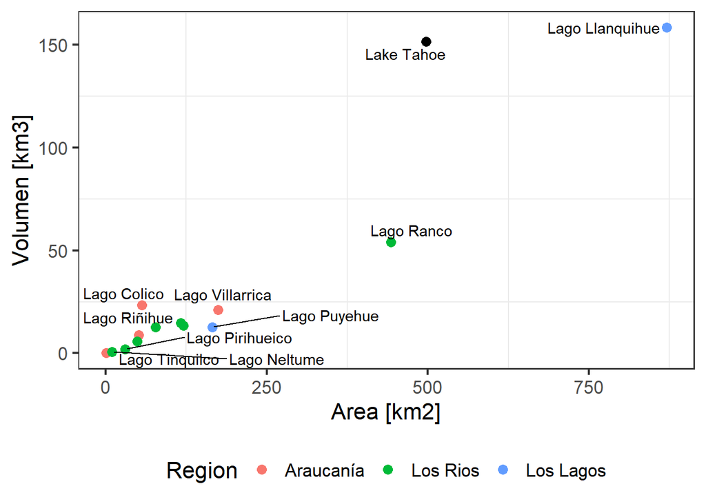

We observe:

- Lago Ranco and Llanquihue are clear outliers in terms of size. Their total size is comparable to Lake Tahoe from California.

We have also the data on how many meteorological stations exist in each lake:

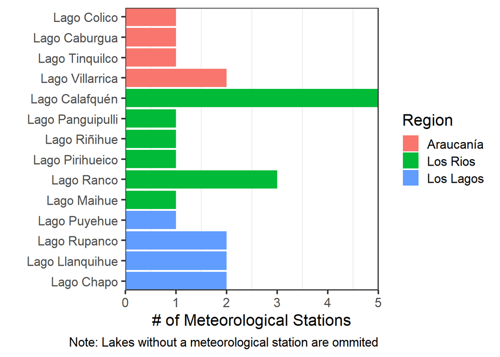

## Social Indicators

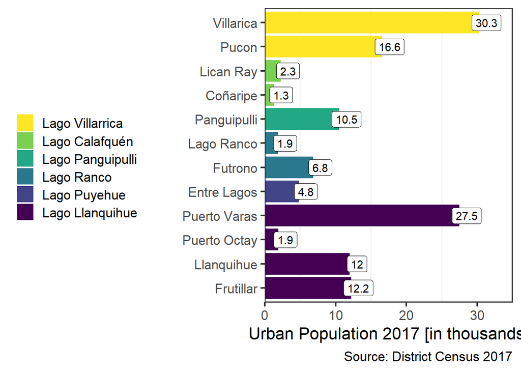

We can also look at the proportion of urban/rural population per commune:

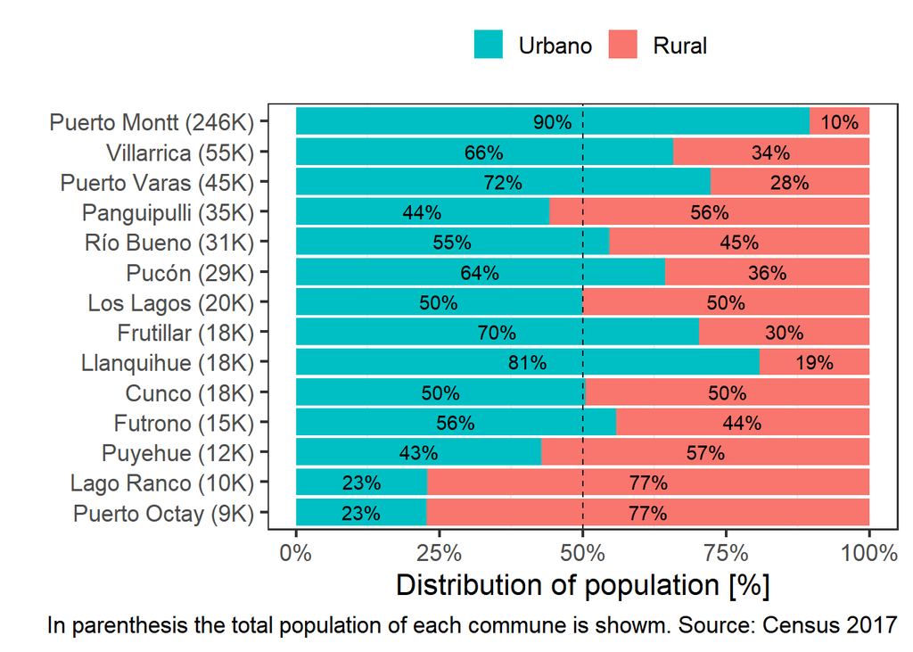

We can see that:

- In general, bigger communes have a greater share of urban population.
- The pattern in the communes of interest does not align with the national averages (88% urban and 12% rural).

Let’s look at the population trend and projected for 2035:

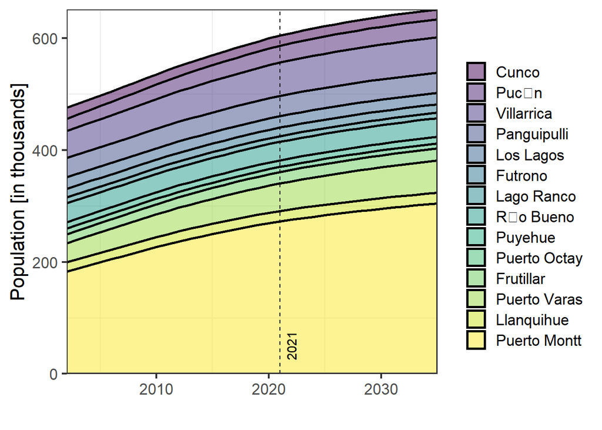

Population projects at this level of detail are not that much useful, as it misses potential changes in status quo such as:

- Migration from Santiago to the south of Chile
- International inmigration

Let’s look at the percentage of people self-identified as belonging to an originary ethnic:

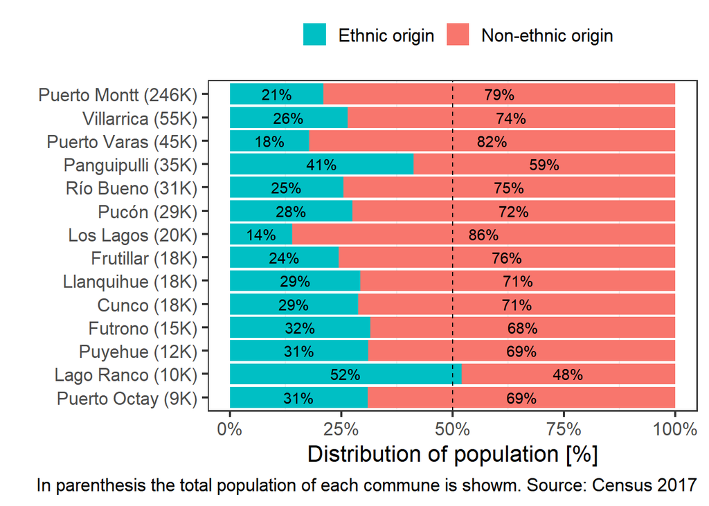

```
## # A tibble: 1 x 3
##        pop   etnic  perc
##      <dbl>   <dbl> <dbl>
## 1 17574003 2089824 0.119
```

```
## # A tibble: 1 x 3
##      pop  etnic  perc
##    <dbl>  <dbl> <dbl>
## 1 558798 138006 0.247
```

Around 11.9% of the national population identified themselves as belonging to an originary ethnic. The communes of interest shows a much higher proportion of 24.7%, with some communes with over 40% of their population belonging to an ethnic.

**TO DO:**

- Number of visitors per year
- Other number of things, like: # of restaurants,# hotels, # of tourism attractions, …